# Artificial Intelligence and Machine Learning

# Limits of Machine Learning

- **Causality vs Correlation**
- Noise in the data or in the labels
- Datasets could have historical bias
- In some cases, ML = blackbox that cannot explain why a prediction was made

# Correlation

[figure not shown]

Graphics from Wikipedia

[figure not shown]

Graphics from [this link](https://wtmaths.com/correlation.html)

# Measuring Correlation

[figure not shown]

| X | Y |
| --- | --- |
| 0.1 | 45 |
| 0.1 | 65 |
| 0.2 | 28 |
| 0.3 | 76 |
| 0.5 | 55 |
| 0.6 | 48 |
| 0.9 | 64 |
| 1.1 | 41 |
| 1.5 | 30 |
| 1.8 | 52 |
| 1.8 | 75 |
| 1.9 | 35 |
| 2.1 | 42 |
| 2.2 | 65 |
| 3.0 | 30 |
| 3.6 | 71 |

# Pearson Correlation Coefficient

$ \rho_{X,Y}= \frac{\operatorname{cov}(X,Y)}{\sigma_X \sigma_Y}$

where:

- $ \operatorname{cov} $ is the covariance of the two series
- $ \sigma_X $ is the standard deviation of $X $
- $ \sigma_Y $ is the standard deviation of $ Y $

# Covariance of two series

The formula for $\rho$ can be expressed in terms of mean and expectation.

$$\operatorname{cov}(X,Y) = \mathbb{E}[(X-\mu_X)(Y-\mu_Y)]$$

So Pearson correlation $\rho$ can also be written as:

$$\rho_{X,Y}=\frac{\mathbb{E}[(X-\mu_X)(Y-\mu_Y)]}{\sigma_X\sigma_Y}$$

- **Normalized Measure of the Covariance**
- Takes values in `[-1,+1]`

# Pearson Correlation Coefficient

- The correlation coefficient ranges from −1 to 1.
- An absolute value of exactly $\pm 1$ implies that a **linear equation describes the relationship between X and Y perfectly, with all data points lying on a line**.
- The correlation **sign is determined by the regression slope**: a value of +1 implies that all data points lie on a line for which Y increases as X increases, and vice versa for −1.
- `0` means that there is no linear dependency between variables

# Pearson Correlation Coefficient Geometry

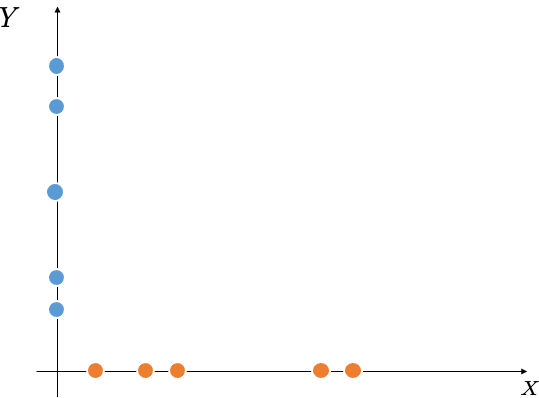

# Pearson Correlation Coefficient Geometry

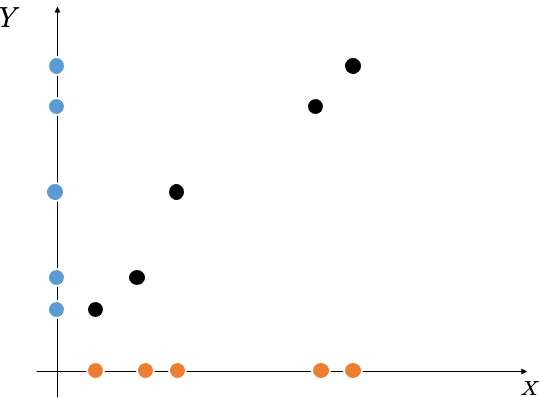

# Pearson Correlation Coefficient Geometry

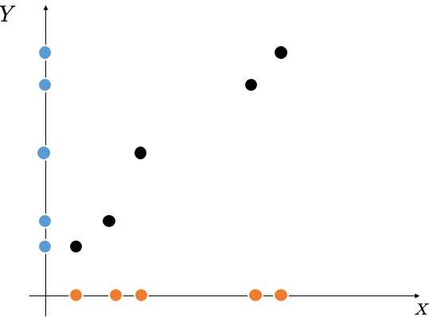

# Pearson Correlation Coefficient Geometry

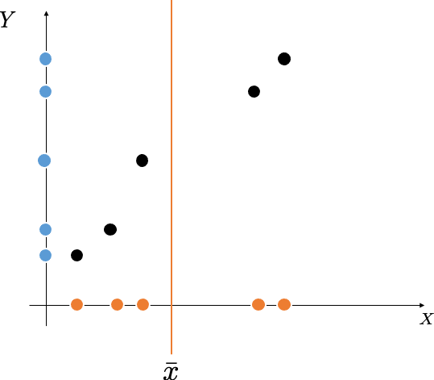

# Pearson Correlation Coefficient Geometry

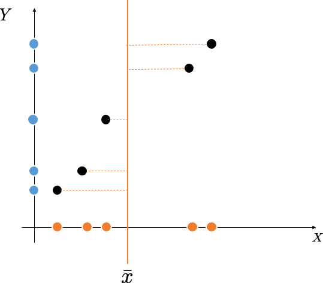

# Pearson Correlation Coefficient Geometry

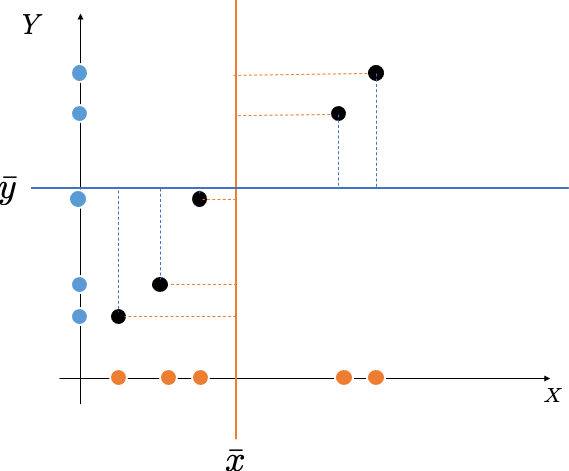

# Pearson Correlation Coefficient Geometry

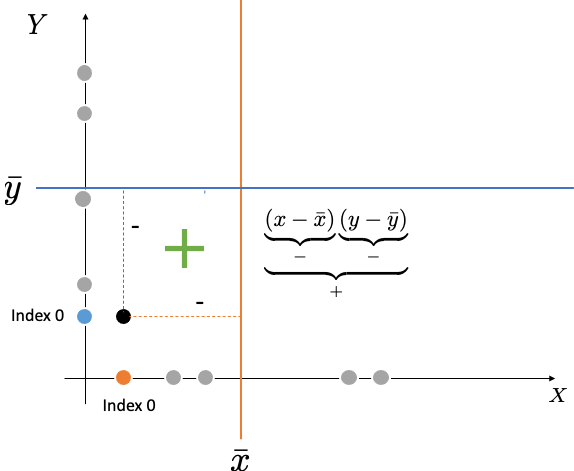

# Pearson Correlation Coefficient Geometry

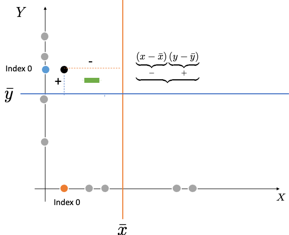

# Pearson Correlation Coefficient Geometry

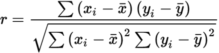

- It takes maximum intensity when the numerator is equal to the denumerator. Otherwise Covariance is Always less than the product of the std. deviation
- The **sign of the covariance** tells you if the data is **correlated** or **anticorrelated**

# Now Interpret again the plot

[figure not shown]

Graphics from Wikipedia

# Final Note: Estimation $\rightarrow$ Predictive Power for Future data

...but we have to be careful when predicting....

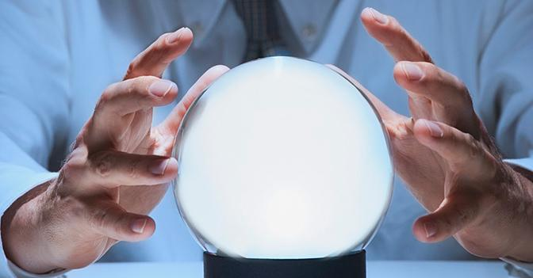

# Final Note: Estimation $\rightarrow$ Predictive Power for Future data

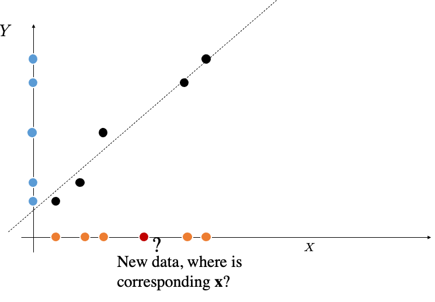

# Final Note: Estimation $\rightarrow$ Predictive Power for Future data

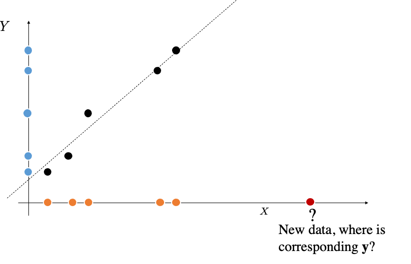

# Final Note: The more Samples you have, the better you predict!

We will see what happens with ML when you have a **low number of samples for training.**

[figure not shown]

# Final Note: The more Samples you have, the better you predict!

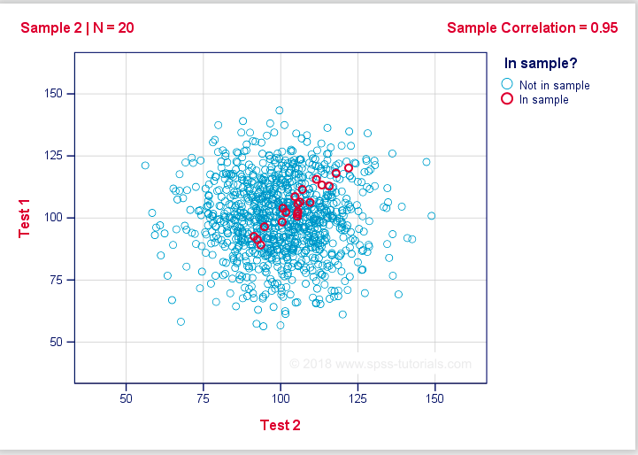

# Correlation DOES NOT imply Causation

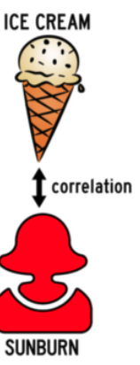

# Correlation DOES NOT imply Causation

[figure not shown]

# Correlation does NOT imply Causation

If given two variable $A$ and $B$, we see that by increasing $A$, $B$ increases as well:

- they are positively correlated *(it could be spurious)*
- It is **NOT** sufficient condition for causality. **It may be OR may be not.**
- It could be that $B \rightarrow A$ or $A \rightarrow B$ (or even that they both co-imply)
- It could also be that another unknown variable $C$, $C \rightarrow A$ and $C \rightarrow B$.

Graphics from [this link](https://sundaskhalid.medium.com/correlation-vs-causation-in-data-science-66b6cfa702f0)

[figure not shown]

Graphics xcd comic

# Spurious Correlations 🤷🏽‍♀️

[figure not shown]

[Check this link out](https://www.tylervigen.com/spurious-correlations)

# Spurious Correlations 🤷🏽‍♀️

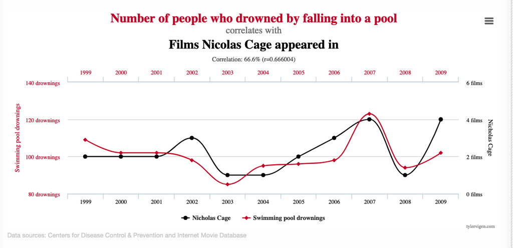

[Check this link out](https://www.tylervigen.com/spurious-correlations)

# Inductive Bias: What We Know Before the Data Arrives

### Let's play a learning "game"

#### Training data

| Class A | Class B |
| --- | --- |

### Classify these images with A or B from left to right, top to bottom

### Write down your answer, then I will ask a few answers

[figure not shown]

#### Training data

| Class A | Class B |
| --- | --- |

#### Test data

[figure not shown]

### Answers?

| parrot | squirrel | cat | penguin |
| --- | --- | --- | --- |
| A | B | B | A |
| A | A | B | B |

- ~70% ABBA prediction (Inferred **bird vs non bird**)
- ~30% AABB (Inferred **fly vs not fly**)

> This preference for one distinction (bird/non-bird) over another (fly/no-fly) is a **bias** that different **human learners** have.

> In the context of machine learning, it is called **inductive bias**: in the absense of data that narrow down the relevant concept, what type of solutions are we more likely to prefer?

# Inductive Reasoning vs Deductive Reasoning

- **Inductive reasoning** is a method of reasoning in which a general principle is derived from a body of observations. It consists of making broad generalizations based on specific observations. The truth of the conclusion of an inductive argument is probable, based upon the evidence given ✅ **(Unit II)**
- **Deductive reasoning** is the mental process of drawing deductive inferences. An inference is deductively valid if its conclusion follows logically from its premises **(Unit I)**

# Inductive Learning

Most of methods covered in this course are **"Inductive"**---as opposed to **transductive**.

# Inductive Learning

- Learn a model $\mbf{\theta}$ on the training set (fix $\mbf{\theta}$, throw away the training set)
- Now, given a new unseen sample $\mbf{x}^{\prime}$ use $\mbf{\theta}$ to predict your result
- Note if you have multiple samples to test, each $\mbf{x}^{\prime}$ is processed independently and one-by-one.

[figure not shown]

# Transductive Learning

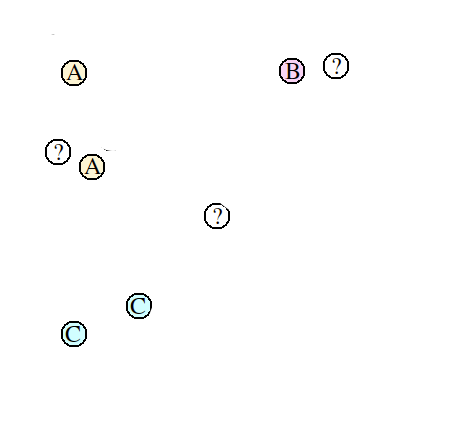

# Transductive Learning

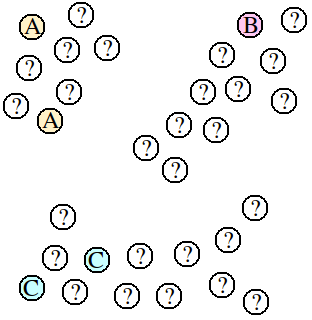

[Vapnik'98 - Learning by Transduction](https://arxiv.org/ftp/arxiv/papers/1301/1301.7375.pdf)

# Learning Paradigms

## 1. Supervised Learning (we have labels)

## 2. Unsupervised Learning (we do NOT have labels)

### There are others: *Reinforcement Learning/Active/Self Supervised Learning (not covered in this course)*

# Introduction to Supervised Learning

Assume that there is a unknown and complex generator $\mathcal{D}$ that provides output pairs $(\mathbf{x},y)$.

- We refer to this **unknown generator process as an unknown probability distribution** $\mathcal{D}$ over input pairs $(\mathbf{x},y) \in \mathcal{X}\times \mathcal{Y}$.
- **Example:** Pairs of images and a label as in the case of bird/non-bird
  - $\mathbf{x}$ corresponds to the image;
  - $y$ to the label
- Given paired $(\mathbf{x},y)$, we learn to predict the label when given as input unseen data.
  - **Classification: the output is a discrete value (category)**
    - Binary Classification (0/1)
    - Multi-Class Classification (1...N)
  - **Regression: the output is a continuous value (real-valued output)**

In practice, in a real-world problem **no one has access to $\mathcal{D}$ because problems are too complex**

> Try to write a computer program to generate all possible natural images that you can find in the world. Is it easy?

Let's assume here that we have access to $\mathcal{D}$ as a python function `get_prob_under_D(x,y)` that takes as input a pair `(x,y)` and returns the probability of the pair under $\mathcal{D}$.

If so, we can define the **Bayes optimal classifier** as the classifier that:

- for any test input $\mathbf{x}^{\prime}$, simply returns the $y^{\prime}$ that maximizes `get_prob_under_D(x,y)`
- Or else, try all possible labels and return the label which yields maximum prob.

\begin{equation} h({x}^{\prime}) = \arg\max_{y^{\prime} \in \mathcal{Y} } \mathcal{D}(x^{\prime},y^{\prime}) \end{equation}

## Take away

The take-home message is that if someone gave you access to the "data distribution", forming an **optimal classifier would be trivial.**

### Real world

Unfortunately, no one gave you the implementation of this distribution.

- We need to figure out ways of **learning the mapping from x to y**
- given **only access to a training set sampled from $\mathcal{D}$**, rather than $\mathcal{D}$ itself.

## Training set

\begin{equation} \underbrace{\{\mathbf{x}_i,y_i\}_{i=1}^N}_{\text{known}} \sim \underbrace{\mathcal{D}}_{\text{unknown}} \end{equation}

where:

- $N$ is the number of training samples
- the vector $\mathbf{x}$ is the input data
- $y$ is the associated (scalar) label

# Supervised Learning

**Goal:** given a training set with labels, learn a function over a set of possible functions (hypothesis over a Hypothesis set)

$$h \in \mathcal{H}\text{ so that }h : \mathbf{x} \mapsto y$$

**Output of the learning is $h(\cdot)$** that can be used to do prediction at test-time.

**Prediction:** Classification (discrete-valued) vs Regression (real-valued output)

[figure not shown]

# Supervised Learning for our game

[figure not shown]

# Cardinal Rule of Machine Learning

The cardinal rule of machine learning is: never touch your test data.

**Ever! If that’s not clear enough:**

## **$\require{color}\colorbox{yellow}{Never ever touch your test data!}$**

There is a specific **validation** set for that.

From cimi book:

> Do not look at your test data. Even once. Even a tiny peek. Once you do that, it is not test data any more. Yes, perhaps your algorithm hasn’t seen it. **But you have. And you are likely a better learner than your learning algorithm.** Consciously or otherwise, you might make decisions based on whatever you might have seen. Once you look at the test data, your model’s performance on it is no longer indicative of it’s performance on future unseen data. This is simply because future data is unseen, but your “test” data no longer is.

# Unsupervised Learning

\begin{equation} \underbrace{\{\mathbf{x}_i\}_{i=1}^N}_{\text{known yet no labels}} \sim \underbrace{\mathcal{D}}_{\text{unknown}} \end{equation}

- We do not have any labels paired with the data.
- Create an internal representation of the input, **capturing regularities/structure** in data
  - Examples: **form clusters**; **extract features**
  - How do we know if a representation is good?

## Clustering (unsupervised)

- Each column is the result of a clustering algorithm
- The input data lives in a 2D space
- Colors indicate the clustering results (which points should be considered together)

[figure not shown]

Image from [scikit-learn](https://scikit-learn.org/stable/modules/clustering.html#clustering)

# Classification as an example

[figure not shown]

# Classification as an example

[figure not shown]

# Classification as an example

[figure not shown]

# Classification as an example

[figure not shown]

# Classification as an example

[figure not shown]

# Classification as an example

[figure not shown]

# Classification as an example

[figure not shown]

# Classification as an example

[figure not shown]

# Classification as an example

[figure not shown]

# Classification as an example

[figure not shown]

# Classification as an example

[figure not shown]

# Classification as an example

[figure not shown]

# Classification as an example

[figure not shown]

# Tools

We are going to use tools such as:

Base programming **Python**

Matrix and array manipulation **Numpy**

Basic ML methods implemented **Scikit Learn**

Plotting and Visualization Tool: **MatplotLib**

## 📝 Course Material & Interaction

#### Google Classroom (Very Important):

- Material uploaded before every lecture (if time permits)
- Use Google Classroom for most and private communication with course staff
- Ask questions about logistics, homework, etc.
- Participate in Q.A. (live) sessions on Zoom

**Very important: write down now!**

# $\colorbox{yellow}{Code to enter classroom: nr6h4g7}$

## classroom.google.com/c/MjEzMzg1MTcyMjda?cjc=nr6h4g7

# The End

Thank you for your attention